# Pilot report: pooling accuracy curves or cutoffs across imputations

A review document: the pilot, its results, the draft spec, and the decisions log

Published

October 29, 2026

# Summary

**Scope.** This document reports the pilot[^1] for the proposal `proposal.md` (“Pool first or optimize first? Cutoffs from multiply imputed biomarker data”): what the idea is, how the pilot was run, what it found, the full draft project spec, and the decisions made along the way. It was built from `project-spec.md`, `decisions.md`, the pre-registration `preregistration.md`, and the saved results in `pilot/results/`, and every number in the text and figures is computed from those files when the document renders. The pilot is a simulation; the NHANES data appear only as a description of the application to come.

**Status.** In `STATUS.md` the pilot is marked `piloted-fail`[^2], by the pre-registered rule. The effect exists, and the spread of the cutoffs predicts it. But pooling first removes 13% of the index’s upward bias in the base cell, where the rule required half, and no difference in the index reaches 0.005. A second reading, set out in the decisions log (D1), keeps the project with Aim 2 leading, because every part of the mechanism the pilot could test held and most of the index’s bias turned out to be the ordinary optimism of a maximum.

| Pilot question | Answer | Key evidence |
| --- | --- | --- |
| 1. Does the effect exist? | yes | base cell gap 0.0028 (MCSE 0.0001); 0 of 500 null replicates nonzero |
| 2. Large enough at realistic n? | not in the index; yes in the cutoff’s accuracy, favouring optimize first | largest gap 0.0049 against 0.01; RMSE ratio of the cutoff, optimize first over pool first, 0.80 (MCSE 0.02) |
| 3. Obvious fix or diagnostic? | a diagnostic, not a fix | correlation of the spread with the gap 0.65 (MCSE 0.03); index bias 0.0190 pool first against 0.0218 optimize first |

**What needs your decision** (details in Action items and limitations): whether the failed pilot leads to a revised proposal and a re-pilot, a re-scope with Aim 2 leading, or a drop; the two yellow `[TO CONFIRM]` items in the spec (the production replicate count and the milestone dates); the five readings of the pass rule the pre-registration made; and two citations named in footnotes that are not in the Zotero library.

# The idea

## In plain language

A blood test gives a number, and a clinic wants one threshold that splits people with a disease from people without it. The usual choice makes sensitivity plus specificity as large as possible (the Youden index[^3]). Suppose the test value is missing for some people, so the analyst fills in the missing values several times over, each time with a different plausible guess, and gets 20 completed datasets (multiple imputation[^4]). Now there are two ways to pick the threshold. One is to find the best threshold in each of the 20 datasets and average the 20 thresholds and the 20 best scores. The other is to average the 20 accuracy curves first and pick the best threshold of the average curve.

The two orders give different scores. Take two datasets whose curves both peak at a score of 0.70, one at threshold 0.9 and the other at 1.1, and both score 0.69 at threshold 1.0, halfway between. Averaging the best scores reports 0.70. The average curve is highest at threshold 1.0, where it scores 0.69. The first order always reports at least as much as the second. What is not known is how large the difference is at the sample sizes and missing fractions of real studies, and whether the spread of the 20 thresholds predicts it. The pilot measures both.

## Potential impact

No published method gives an optimal cutoff, its index, and their uncertainty from multiply imputed data. The default analysis runs in each completed dataset and combines the results with Rubin’s rules[^5], which average the estimates and add their spread to the variance, and for an optimal cutoff that default has no theory behind it. Rubin’s rules assume each completed-data estimate is close to normally distributed (Leyrat et al. 2019), while the empirical optimal cutoff is the maximizer of a step function and converges at a slower, cube-root rate to a non-normal limit (Kim and Pollard 1990). The closest prior work, Long, Zhang, and Hsu (2011), imputed a missing depression score, averaged the true and false positive rates across imputations at each threshold, and read off the threshold that maximizes their sum; it reported no uncertainty for that threshold. Applied studies that impute and then report an optimal cutoff leave the order of the two steps unstated (Abdulrahman et al. 2022; Atlantis et al. 2016).

The problem is a reporting error that more imputations do not cure. The averaged-maxima index is never smaller than the maximum of the averaged curve, and the excess is set by how far the per-dataset cutoffs scatter, which is a property of the missing data and not of the number of imputations. An analyst who reads the index off the averaged curve, and reports a band for the whole curve with a set of near-optimal thresholds in place of an interval for the cutoff, avoids it.

The users are diagnostic-accuracy and prediction studies that impute a missing marker and publish an optimal cutoff, in laboratory medicine, epidemiology, and psychiatry. If the gap is large at realistic sizes, the indices those studies report overstate the accuracy of their cutoffs and the reporting changes. If it is small, the case for the proposed reporting rests on inference, which no current method supplies. The pilot puts the gap at 0.0028 in the base cell (Figure 4), below the pre-registered 0.01, so the impact lies on the inference side: the spread of the cutoffs is a diagnostic an analyst can compute (Figure 5), and the pointwise intervals that Rubin’s rules give for the curve undercover once many values are missing (Figure 7).

## Application: the study behind the data

### The study

The National Health and Nutrition Examination Survey[^6] (NHANES) samples the noninstitutionalized United States population in two-year cycles, interviews each participant, and examines a subsample in a mobile examination center, where blood is drawn. Serum cotinine[^7], the main metabolite of nicotine, was measured in examined participants aged 3 and over in the cycles 2013-2014, 2015-2016, and 2017-2018, with the same laboratory method (isotope-dilution liquid chromatography with tandem mass spectrometry) and the same lower limit of detection, 0.015 ng/mL; values below it are set to the limit divided by the square root of two (documentation files `COT_H`, `COT_I`, and `COT_J`, read 2026-10-28). Adults answer a smoking questionnaire (`SMQ`). The files are public at wwwn.cdc.gov/Nchs/Data/Nhanes/Public/, with no login.

Two studies used these survey data to choose a cotinine cutoff for current smoking. Benowitz, Bernert, Caraballo, Holiday, and Wang (2009), *American Journal of Epidemiology* 169(2):236-48 (doi:10.1093/aje/kwn301), used the cycles 1999 to 2004 and found that optimal cutoffs differed by race/ethnicity, 5.92 ng/mL for non-Hispanic Black, 4.85 for non-Hispanic White, and 0.84 for Mexican American adults. Tompkins, Beltran, and Bedno (2019), *Biomarkers in Medicine* 13(12):1025-1033 (doi:10.2217/bmm-2019-0027), used the cycles 2009 to 2014 and found an adult cutoff of 3.63 ng/mL that differed by sex and race/ethnicity. In the three cycles used here, 17,948 adults answered the smoking question, 3,353 of them current smokers[^8], and cotinine is missing for 9.6% of them (Table 1).

Table 1: Adults aged 18 and over with an answer to the smoking question, by NHANES cycle: current smokers, nonsmokers, participants not examined, participants with serum cotinine missing (of whom some were examined), values below the limit of detection, and the share missing. Computed from the downloaded NHANES files by pilot/nhanes.R (results/nhanes_summary.rds).

|  | Cycle | Adults | Smokers | Nonsmokers | Not examined | Cotinine missing | Missing, examined | Below detection | Share missing |
| --- | --- | --- | --- | --- | --- | --- | --- | --- | --- |
| 2013-2014 | 2013-2014 | 6,111 | 1,232 | 4,879 | 189 | 471 | 282 | 1,759 | 7.7% |
| 2015-2016 | 2015-2016 | 5,981 | 1,100 | 4,881 | 256 | 586 | 330 | 1,794 | 9.8% |
| 2017-2018 | 2017-2018 | 5,856 | 1,021 | 4,835 | 323 | 658 | 335 | 1,783 | 11.2% |
| 1 | All three | 17,948 | 3,353 | 14,595 | 768 | 1,715 | 947 | 5,336 | 9.6% |

### Why the Youden index

A cotinine cutoff classifies a participant as a smoker when the measured value exceeds it, and the Youden index of a cutoff, sensitivity plus specificity minus one, is the share of smokers called smokers minus the share of nonsmokers called smokers. Both cotinine studies chose the cutoff that maximizes it. The estimand is the maximizer of the population Youden curve and the curve’s maximum; the question here is how to estimate both, with their uncertainty, when some cotinine values are missing and imputed. The proposed analysis imposes missingness at random on the adults with observed cotinine, so that the full-data cutoff is the benchmark, imputes, and compares the two pooling orders, overall and by race/ethnicity.

### Did the original study compute it?

Partly. Both studies estimated the optimal cutoff from receiver operating characteristic curves on participants with observed cotinine, and Benowitz et al. estimated it within race/ethnicity groups. Neither study imputed the missing cotinine values, and neither reported the uncertainty of its cutoff in the passages read for this project. The question here is new: how the cutoff, its index, and their uncertainty should be pooled once missing values are imputed, and whether the stratum-specific cutoff or the cutoff that is optimal for the population as a whole is the target within each race/ethnicity group.

## In symbols

Each group’s marker distribution ($F_0$ for nonsmokers or the healthy group, $F_1$ for smokers or the diseased group), a threshold ($c$), the Youden curve ($J(c)$), its maximizer and maximum ($c^*$ and $J^*$), the curve of the $l$-th of $L$ completed datasets ($\hat J_l$) and its maximizer ($\hat c_l$), the averaged curve ($\bar J$), and the spread of the per-dataset cutoffs ($\hat B_c$) are related by

$$\begin{aligned}
J(c) &= F_0(c) - F_1(c), \qquad c^* = \arg\max_c J(c), \qquad J^* = J(c^*) \\
\bar J(c) &= \frac{1}{L}\sum_{l=1}^{L} \hat J_l(c), \qquad \hat B_c = \frac{1}{L}\sum_{l=1}^{L} (\hat c_l - \bar c)^2 \\
\text{P1 (pool first)} &: \ \hat c_{\mathrm{P1}} = \arg\max_c \bar J(c), \qquad \hat J_{\mathrm{P1}} = \max_c \bar J(c) \\
\text{P2 (optimize then mean)} &: \ \hat c_{\mathrm{P2}} = \bar c, \qquad \hat J_{\mathrm{P2}} = \frac{1}{L}\sum_{l=1}^{L} \max_c \hat J_l(c) \\
G &= \hat J_{\mathrm{P2}} - \hat J_{\mathrm{P1}} \ \ge\ 0.
\end{aligned}$$

| Symbol | Meaning |
| --- | --- |
| $X$, $D$, $Z$ | the marker, the disease status (0 or 1), the auxiliary variable that predicts the marker |
| $F_d$ | distribution function of $X$ in group $D = d$ |
| $J(c)$, $c^*$, $J^*$ | the Youden curve, its maximizer, its maximum |
| $\kappa$, $\tau$ | curvature $-J''(c^*)$ and third derivative $J'''(c^*)$ at the peak |
| $L$, $\hat J_l$, $\hat c_l$ | number of imputations, curve and maximizer of completed dataset $l$ |
| $\bar J$, $\bar c$, $\hat B_c$ | averaged curve, mean of the $\hat c_l$, their spread |
| P1, P2, P3 | pool first; optimize then mean; optimize then median (the averaged curve read at the median of the $\hat c_l$) |
| $G$ | the gap, P2’s index minus P1’s |

The target is $c^*$ and $J^*$. What can be computed is one of the pooled pairs, P1 or P2, from the completed datasets. The inequality $G \ge 0$ holds in every dataset: each $\hat J_l(c)$ is at most its own maximum, so the average of the curves is at most the average of the maxima at every $c$. If every curve is a parabola near its peak with curvature $\kappa_l$, the gap is exactly $L^{-1}\sum_l (\kappa_l/2)(\hat c_l - \tilde c)^2$, with $\tilde c$ the curvature-weighted mean of the $\hat c_l$; with equal curvatures it is $\kappa \hat B_c / 2$. In words: the gap is half the sharpness of the peak times the spread of the cutoffs across imputations, and that spread does not shrink when more imputations are drawn. A third-order term moves the pooled cutoff from $\bar c$ by about $\tau \hat B_c / (2\kappa)$, zero for a symmetric peak.

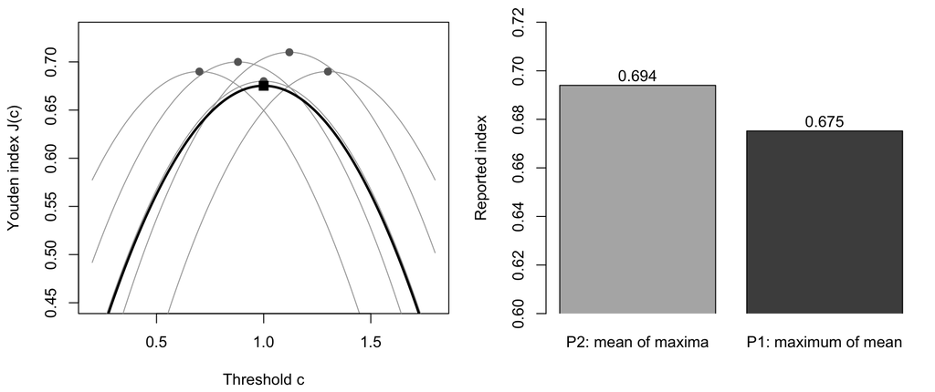

Figure 1: The idea, on made-up numbers (an illustration, not pilot output). Left: five completed-data Youden curves (grey), each a parabola with its own peak (dots), and their average (black), whose peak is the square. Right: the index each order reports. The mean of the five maxima (P2) exceeds the maximum of the averaged curve (P1) by half the curvature times the spread of the five peak locations.

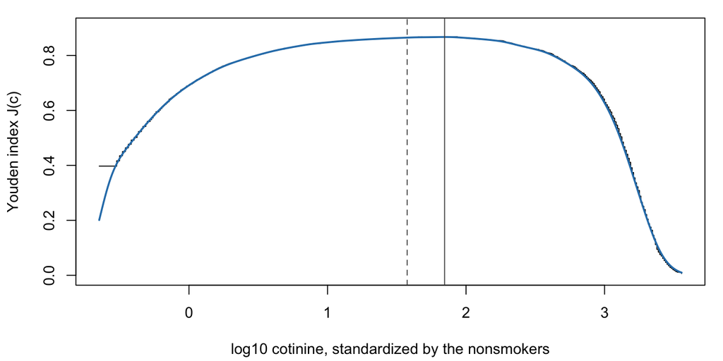

Figure 2: The real data: the full-data Youden curve of log serum cotinine among NHANES adults (2013 to 2018, participants with cotinine observed), current smokers against everyone else, on the scale used in the simulation (log cotinine standardized by the nonsmokers’ mean and standard deviation). Black: the empirical curve; blue: the Gaussian-kernel curve. The solid vertical line is the maximizer of the kernel curve; the dashed line is the adult cutoff of 3.63 ng/mL of Tompkins, Beltran, and Bedno (2019). From results/nhanes_summary.rds.

The full-data curve peaks at 7.35 ng/mL with an index of 0.868 (empirical curve); at the published adult cutoff of 3.63 ng/mL the empirical index is 0.865, lower by 0.003 for a cutoff half as large. The curve is flat over that range, which is the situation in which per-dataset cutoffs scatter. On the standardized scale its curvature at the peak is 0.229, between the flat (0.220) and the sharp (0.484) shapes of the simulation, and its maximum, 0.867, is above both. The cutoff here is higher than the published ones; the definitions differ, since everyone who is not a current cigarette smoker, including users of other tobacco products, counts as a nonsmoker here.

## Critiquing the model

Any model is a simplification, and the useful question is not whether it is true but where it bends and whether the bend matters for the question being asked. The model above was chosen so that the problem could be written as a formula and checked by simulation, and each simplification that made that possible is a place where real data may behave differently. The table lists the main ones. Work through it one row at a time. The first column names the feature and the symbols in the equations that carry it, so find them there first. Then decide in your own words how the feature could fail for real data before reading the second column, and finally read the third column for what should be done to check it. Several of these checks are natural first tasks for the project. Which of them the pilot examined, and which it left open, is for you to find when you read the Methods and Results that follow.

[output not shown]

# Methods

## Design

The pilot simulates a binormal marker that is missing at random through one auxiliary, imputes it 20 times, estimates the Youden curve in each completed dataset with two estimators, and pools the results by the three rules. Part A is the main grid: two peak shapes, three missing fractions (0%, 40%, 60%), two sample sizes, and two imputation engines, predictive mean matching[^9] and the nearest-neighbour method of Long, Zhang, and Hsu (2011)[^10], with the 0% cells needing no imputation. Part B varies the number of imputations $L$ (5, 20, 100) in the base cell. Each of the 22 simulated settings (data cells) is analysed by both estimators on the same completed datasets, for 44 analysis cells and 500 replicates per cell. The known-answer checks run the same code on cases with known answers.

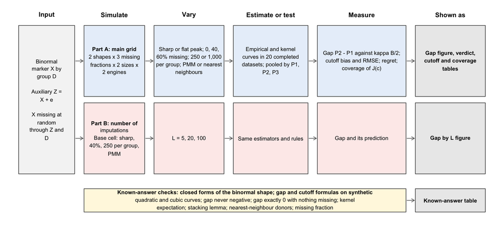

Figure 3: The design at a glance. Each row is one part of the pilot, read from left to right: what is simulated, which factors are varied, what is estimated, what is measured, and how the result is shown. The input is the binormal marker model with one auxiliary. Part A’s gap is shown in the gap figure (Figure 4) and the verdict table (Table 3), its cutoff errors in Table 5, and its coverage in Figure 7; Part B’s gap by number of imputations in Figure 6; the base cell’s replicates in Figure 5; the checks in Table 2.

Each figure and table in the Results traces back to one row of this diagram, and the row says what its points or entries represent.

| Part | What is simulated | Main factors | Replicates |
| --- | --- | --- | --- |
| A | $X \mid D{=}0 \sim N(0,1)$, $X \mid D{=}1 \sim N(\delta, \sigma_1^2)$; $Z = X + e$; $X$ missing with probability $\mathrm{expit}(\alpha_0 + Z + 0.5D)$ | shape, missing fraction, $n$ per group, engine; $L = 20$ | 500 per cell, 20 data cells |
| B | the base cell of part A | $L$ = 5, 100 (and 20 from part A) | 500 per cell, 2 data cells |

The sharp shape has $\delta = 2$ and $\sigma_1 = 1$: a symmetric peak at $c^* = 1.000$ with $J^* = 0.6827$ and curvature $\kappa = 0.484$. The flat shape has $\delta = 1.5$ and $\sigma_1 = 2.5$: an asymmetric peak at $c^* = 1.355$ with $J^* = 0.4354$, $\kappa = 0.220$, and $\tau = 0.159$. The intercept $\alpha_0$ is solved so that the expected missing fraction is the target; missing values fall mostly at high $Z$, where the diseased group sits, so donors are sparse near and above $c^*$. Predictive mean matching uses 5 donors and the predictors $D$, $Z$, and $D \times Z$; the nearest-neighbour method uses 3 neighbours on two standardized scores with its bootstrap step, which with one auxiliary picks the 3 nearest observed subjects in $Z$ within the same group. The empirical curve’s cutoff is the midpoint of the maximizing interval (the mean of the midpoints when intervals tie); the kernel curve uses Gaussian kernels with Silverman’s bandwidth[^11] per group and per completed dataset. The pointwise interval for $J(c)$ combines the 20 completed-data estimates by Rubin’s rules with the binomial within-imputation variance. The base cell is the sharp shape, 40% missing, 250 per group, predictive mean matching, $L = 20$, empirical estimator; its kernel twin is the same data analysed with the kernel estimator.

## Known-answer checks

Known-answer checks come before any result, because every later number is only as good as the simulation that produced it. Each check sets up a case where the correct answer is known from theory, runs the simulation code on it, and compares the two. Agreement says nothing about the scientific question or about real data. It says that the code does what the model says. Disagreement means stopping to look for a bug before reading anything else, and the same checks apply to any code you write for the project.

Read each row of the table in four steps: the setting that was simulated, the known answer for that setting, what the simulation gave, and whether the gap between the two is small compared with the Monte Carlo standard error (MCSE). The MCSE is how much a simulated result moves from run to run because only a finite number of replicates was used. A gap within about two MCSE is noise, and a gap of several MCSE is a problem.

Table 2: Known-answer checks, from results/known_answers.rds (written by pilot.R before the run, the same checks the test suite asserts) and, for the last three rows, from results/cell_summaries.rds (the pilot’s own null cells).

| Check | Setting | Known answer | Simulation gave | How to read it |
| --- | --- | --- | --- | --- |
| Optimal cutoff | sharp shape | c* = 1 | 1 | 1.792e-09 from the known value, against a tolerance of 1e-06, so the check passes. |
| Maximum of J | sharp shape | J* = 2 Phi(1) - 1 | 0.682689 | 1.11e-16 from the known value, against a tolerance of 1e-10, so the check passes. |
| Curvature at c* | sharp shape | kappa = 2 phi(1) | 0.483941 | 0 from the known value, against a tolerance of 1e-06, so the check passes. |
| Pool-first cutoff | 7 quadratic curves | curvature-weighted mean of the cutoffs | 0.972992 | 3.997e-15 from the known value, against a tolerance of 1e-10, so the check passes. |
| Gap | 7 quadratic curves | mean of kappa_l (c_l - c_tilde)^2 / 2 | 0.00195902 | 9.628e-17 from the known value, against a tolerance of 1e-10, so the check passes. |
| Cutoff difference | 7 cubic curves, spread 0.01 | ratio to tau B / (2 kappa) is 1 | 1.0017 | 0.001717 from the known value, against a tolerance of 0.01, so the check passes. |
| Gap never negative | 1,000 sets of 5 random curves | smallest gap >= 0 | 0.0151 | The smallest gap is 0.0151, not negative, so the check passes. |
| Gap with nothing missing | 20 copies, empirical | exactly 0 | 0 | 0 from the known value, against a tolerance of 0, so the check passes. |
| Gap with nothing missing | 20 copies, kernel | exactly 0 | 0 | 0 from the known value, against a tolerance of 0, so the check passes. |
| Kernel distribution function | fixed h = 0.3, 2,000 samples of 200, c = 0.5 | Phi(c / sqrt(1 + h^2)) | 0.6830 (MCSE 0.0006) | 1.6 MCSE from the known value, so the gap is noise. Judged at 3 MCSE, the pilot’s rule. |
| Stacking lemma | 10 imputations, empirical | stacked curve equals averaged curve | 1.11022e-16 | 1.11e-16 from the known value, against a tolerance of 1e-12, so the check passes. |
| Nearest-neighbour donors | one auxiliary, k = 3 | subjects not matching a literal search in Z | 0 | 0 from the known value, against a tolerance of 0, so the check passes. |
| Missing fraction | flat shape, 200,000 subjects | target 0.40 | 0.4014 (MCSE 0.0011) | 1.2 MCSE from the known value, so the gap is noise. Judged at 3 MCSE, the pilot’s rule. |
| Gap with nothing missing | all 8 null analysis cells of the pilot | exactly 0 in every replicate | 0 nonzero of 4000 | No replicate has a nonzero gap, so the check passes. |
| Full-data cutoff | sharp, 0%, 1,000 per group, empirical | c* = 1 (symmetry) | 1.0013 (MCSE 0.0047) | 0.3 MCSE from the known value, so the gap is noise. Judged at 3 MCSE, the pilot’s rule. |
| Full-data cutoff | sharp, 0%, 1,000 per group, kernel | c* = 1 (symmetry) | 1.0010 (MCSE 0.0022) | 0.4 MCSE from the known value, so the gap is noise. Judged at 3 MCSE, the pilot’s rule. |

0 of 4 rows with a standard error are more than 3 MCSE from the known value. The rows without a standard error are exact identities or bounds, judged against a tolerance.

# Results

## How to read the outputs

Each output traces back to a row of the design diagram (the captions name the part where one applies). Read each in the same four steps. First, find its row in the diagram, which says what was simulated and what was varied. Second, work out what one point or one table entry is, usually one combination of the varied factors, averaged over replicates. Third, identify the reference value that would hold if nothing were wrong, shown as a dashed or grey line wherever possible. Fourth, look for where the results leave that reference, and for which settings they do. The outputs report three kinds of quantity.

- **Bias** is the average of an estimate minus its true value. When the truth is no difference, any average difference from 0 is a spurious difference created by the problem under study.
- **Level** is how often a test rejects when there is truly nothing to find. A correct test at 0.05 rejects 5% of the time, so a rate above 0.05 means too many false alarms.
- **Power** is how often a test rejects when there is a real effect. More is better, but only when the level is not inflated, because a test that rejects too often also looks powerful.

All rates and averages come from simulation, so each carries Monte Carlo error. That is why the figures show bars or a grey band, and why small differences should not be over-read.

This pilot has no test, so level and power do not arise; it reports three further quantities. The gap is the index reported by optimizing in each completed dataset and averaging (P2) minus the maximum of the averaged curve (P1), averaged over replicates; it is never negative, and it is zero exactly when nothing is missing. The predicted gap is $\kappa \hat B_c / 2$, half the true curvature at the peak times the spread of the 20 per-dataset cutoffs in the same replicate; the ratio of the mean gap to the mean predicted gap is 1 when the quadratic formula holds. The coverage of an interval is the share of replicates in which it contains the true value, 0.95 for a correct 95% interval.

## The gap between the two orders

**Figure guide (part A, every cell with missing values).** If the mechanism holds, every mean gap is positive and the kernel estimator’s gaps sit near their predicted values. One point is one analysis cell: the mean gap over 500 replicates, with a bar of plus and minus two MCSE; filled points are predictive mean matching, open points nearest neighbours; a cross marks the mean predicted gap $\kappa \hat B_c / 2$. The dashed line is the pre-registered threshold of 0.01 and the dotted line 0.005. Look for: which cells, if any, reach the dashed line; whether the gap grows from 40% to 60% missing and shrinks from 250 to 1,000 per group; whether the crosses sit on the points for the kernel estimator and for the empirical one.

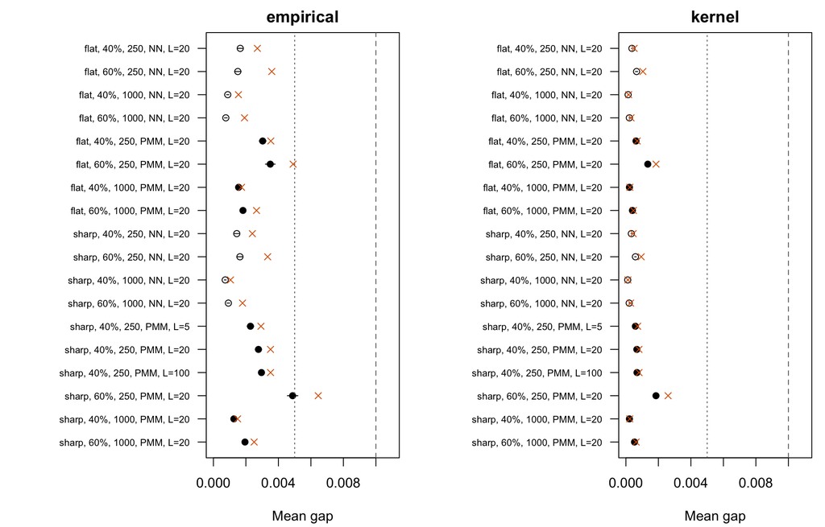

Figure 4: Part A and B: the mean gap (P2 index minus P1 index) in every analysis cell with missing values, with plus and minus two MCSE, by estimator. Filled: predictive mean matching (PMM); open: nearest neighbours (NN); crosses: the mean predicted gap. Dashed and dotted lines: 0.01 and 0.005. From results/cell_summaries.rds.

**Figure guide (base cell, replicate by replicate).** If the spread of the per-dataset cutoffs is the diagnostic the mechanism says, replicates with a larger spread have a larger gap. One point is one replicate of the base cell. Left: the empirical estimator’s gap against the spread $\hat B_c$ of its 20 cutoffs. Right: the kernel estimator’s gap against its predicted value $\kappa \hat B_c / 2$, with the identity line dashed. Look for: how tightly the points follow a line on the left; whether the right panel’s points scatter around the dashed line or fall consistently above or below it.

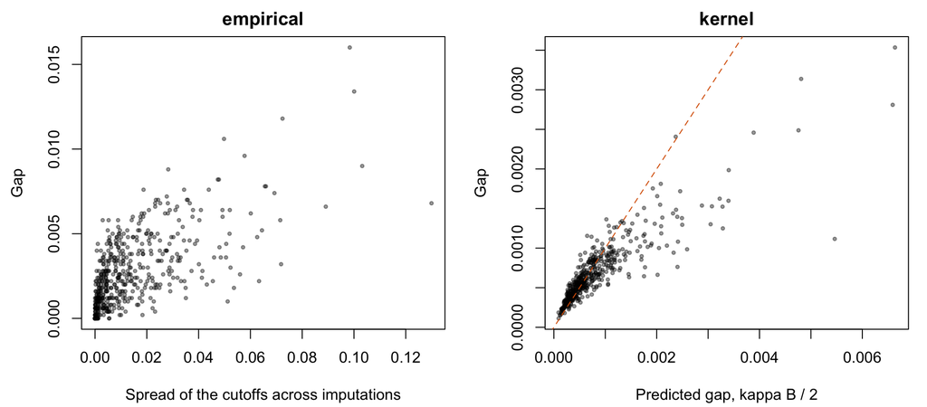

Figure 5: Base cell (sharp, 40% missing, 250 per group, PMM, L = 20), all 500 replicates. Left: empirical estimator, gap against the spread of the 20 per-dataset cutoffs. Right: kernel estimator, gap against the predicted gap, identity line dashed. From results/base_cell_points.rds.

**Figure guide (part B, the number of imputations).** The mechanism says the gap does not shrink as $L$ grows, because the spread of the cutoffs is a property of the missing data. One point is the mean gap in the base cell at $L$ = 5, 20, or 100, with plus and minus two MCSE; crosses are the mean predicted gaps. Look for: whether the gap at $L = 100$ is smaller than at $L = 20$ by more than its bars; whether the two estimators move the same way.

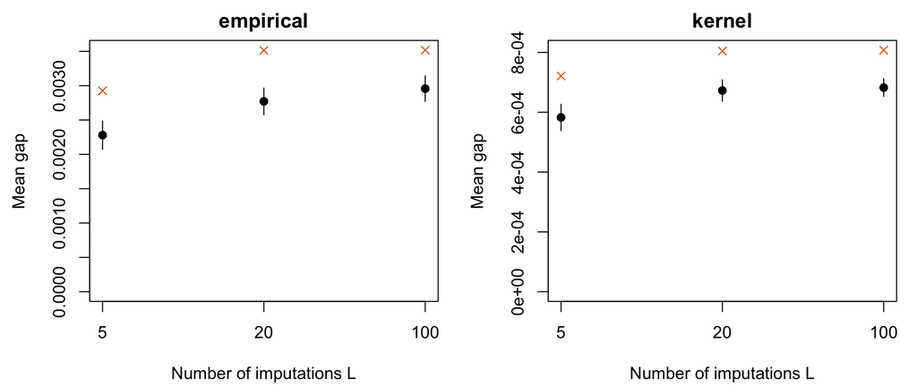

Figure 6: Part B: the mean gap in the base cell (sharp, 40% missing, 250 per group, PMM) by the number of imputations L, with plus and minus two MCSE, for each estimator. Crosses: the mean predicted gap. From results/cell_summaries.rds.

## Coverage of the pointwise interval

**Figure guide (part A, every cell).** A correct 95% interval for $J(c)$ at a fixed threshold covers in 95% of replicates. One point is one analysis cell’s coverage at $c^*$ (black), at $c^* - 0.5$ (blue), or at $c^* + 0.5$ (orange); the grey band is 0.95 plus and minus two binomial standard errors at 500 replicates; the dashed lines are the pre-registered limits 0.92 and 0.98. Look for: whether the null cells, where nothing is imputed, cover near 0.95 for each estimator; which threshold and which estimator fall below the band once values are missing.

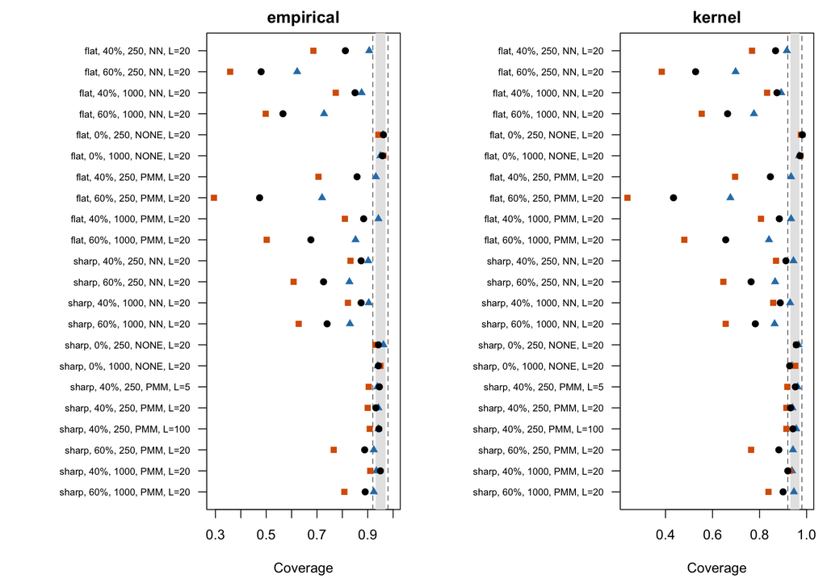

Figure 7: Part A and B: coverage of the pointwise 95% Rubin’s-rules interval for J(c) at c* (black), c* - 0.5 (blue), and c* + 0.5 (orange) in every analysis cell, by estimator. Grey band: 0.95 plus and minus two binomial standard errors; dashed lines: 0.92 and 0.98. From results/cell_summaries.rds.

## Numbered findings

Each finding is a claim followed by the output behind it. Read the claim, open the output, and check that you can see the claim there before accepting it. A claim that cannot be seen in the output is a question to raise with the user.

1. **The gap exists in every cell with missing values and is exactly zero without them.** In the base cell the mean gap is 0.0028 (MCSE 0.0001), 29 MCSE above zero, and 0 of the 4,000 null replicates have a nonzero gap (Figure 4; Table 3; Table 2).
2. **The gap is small at realistic sizes.** Across the predictive-mean-matching cells it runs from 0.0002 to 0.0049; the largest, 0.0049, is in the cell sharp, 60%, 250, PMM, L = 20, empirical, below the 0.01 and 0.02 thresholds and below the proposal’s 0.005 line for a negative result. The kernel estimator’s gaps are smaller, 0.0002 to 0.0019 (Figure 4; Table 4).
3. **The spread of the cutoffs predicts the gap, and for the kernel curve with 40% missing the closed form holds once the pooled curve’s own curvature is used.** The correlation of $\hat B_c$ with the gap runs from 0.56 to 0.92 across the predictive-mean-matching cells. For the kernel estimator the ratio of the mean gap to $\kappa \hat B_c / 2$ with the true curvature runs from 0.71 to 0.90, because smoothing flattens the peak. With the pooled curve’s own curvature the ratio runs from 0.97 to 1.00 with 40% missing and from 0.59 to 0.98 with 60%, where replicates with widely spread cutoffs fall below the prediction (Figure 5; Table 4).
4. **The gap does not shrink as the number of imputations grows.** In the base cell it is 0.0023, 0.0028, and 0.0030 at $L$ = 5, 20, and 100 (MCSE about 0.0001), rising toward its limit as the spread of the cutoffs is estimated with less downward bias (Figure 6).
5. **The gap shrinks with the sample size, at about the rates the theory gives.** From 250 to 1,000 per group the base cell’s gap falls by a factor of 0.45 for the empirical estimator, against $4^{-2/3} = 0.40$ for a cube-root estimator, and by 0.32 for the kernel estimator, against $4^{-1} = 0.25$ for a regular one (Table 4; a secondary measure, with no pass rule).
6. **Pooling first removes a small share of the index’s upward bias.** In the base cell the pool-first index exceeds $J^*$ by 0.0190 (MCSE 0.0017) and the optimize-first index by 0.0218 (MCSE 0.0017), a ratio of 0.87 (MCSE 0.01) against the required 0.5. With nothing missing the empirical maximum already exceeds $J^*$ by 0.0170 (MCSE 0.0014), so most of the bias is the optimism of a maximum, not the pooling order (Table 5).
7. **For the empirical curve the optimize-first cutoff is the more accurate one.** The ratio of root mean squared errors of the cutoff, optimize first over pool first, runs from 0.80 to 0.90 across the predictive-mean-matching cells, and its regret is lower in 10 of these 10 cells (0.0048 against 0.0075 in the base cell); for the kernel curve the ratio is 0.96 to 0.99, so the two orders give nearly the same cutoff (Table 5).
8. **The pointwise interval for $J(c)$ covers in the null cells and undercovers once missing values are many or the peak is flat.** Coverage runs from 0.928 to 0.982 in the null cells, from 0.238 to 0.962 in the predictive-mean-matching cells, lowest at $c^* + 0.5$ with 60% missing and the flat shape, and from 0.358 to 0.944 in the nearest-neighbour cells. In the flat cells with 60% missing the empirical cutoff is biased by -0.24 to -0.04 under pool first: the imputations, not the pooling, are biased where donors are sparse (Figure 7; Table 5).
9. **The nearest-neighbour engine gives smaller gaps and worse coverage than predictive mean matching.** Its empirical gaps run from 0.0007 to 0.0017 and its ratios to the prediction from 0.40 to 0.69; with one auxiliary its donors are the same 3 subjects in every imputation (decisions log, D5), so the imputations vary less than they should (Figure 4; Table 4; Figure 7).

## Tables

**Table guide (the verdict).** One row is one criterion of the pre-registered pass rule: the cell it is judged in, the measure, its estimate with its MCSE, the threshold, whether the threshold is met, and whether the estimate lies within three MCSE of the threshold (near). Question 2’s clause (c) has one row per predictive-mean-matching cell with missing values. Which criteria decide each answer, and are any of the deciding ones near their thresholds?

Table 3: The pass rule applied to the pilot (pilot/verdict.R, results/verdict.rds): every criterion of the pre-registration, its estimate and MCSE, its threshold, and whether it is met or near (within three MCSE of the threshold).

| Question | Clause | Cell | Measure | Estimate | MCSE | Threshold | Met | Near |
| --- | --- | --- | --- | --- | --- | --- | --- | --- |
| Q1 | a | base (sharp, 40%, 250, PMM, L = 20, empirical) | mean gap | 0.0028 | 0.0001 | > 3 MCSE | yes |  |
| Q1 | b | null (sharp, 0%, 250, empirical) | replicates with a nonzero gap | 0 |  | = 0 | yes |  |
| Q2 | a | base (sharp, 40%, 250, PMM, L = 20, empirical) | mean gap | 0.0028 | 0.0001 | >= 0.01 | no |  |
| Q2 | a | base, kernel | mean gap | 0.0007 | 0.0000 | >= 0.01 | no |  |
| Q2 | b | 60% (sharp, 250, PMM, empirical) | mean gap | 0.0049 | 0.0002 | >= 0.02 | no |  |
| Q2 | b | 60% (sharp, 250, PMM, kernel) | mean gap | 0.0019 | 0.0001 | >= 0.02 | no |  |
| Q2 | c | sharp, 40%, 250, PMM, L = 20, empirical | RMSE ratio of the cutoff, P2 over P1 | 0.7995 | 0.0159 | >= 1.10 or <= 0.90 | yes |  |
| Q2 | c | sharp, 40%, 250, PMM, L = 20, kernel | RMSE ratio of the cutoff, P2 over P1 | 0.9882 | 0.0026 | >= 1.10 or <= 0.90 | no |  |
| Q2 | c | sharp, 60%, 250, PMM, L = 20, empirical | RMSE ratio of the cutoff, P2 over P1 | 0.8137 | 0.0149 | >= 1.10 or <= 0.90 | yes |  |
| Q2 | c | sharp, 60%, 250, PMM, L = 20, kernel | RMSE ratio of the cutoff, P2 over P1 | 0.9581 | 0.0072 | >= 1.10 or <= 0.90 | no |  |
| Q2 | c | sharp, 40%, 1000, PMM, L = 20, empirical | RMSE ratio of the cutoff, P2 over P1 | 0.8171 | 0.0152 | >= 1.10 or <= 0.90 | yes |  |
| Q2 | c | sharp, 40%, 1000, PMM, L = 20, kernel | RMSE ratio of the cutoff, P2 over P1 | 0.9912 | 0.0013 | >= 1.10 or <= 0.90 | no |  |
| Q2 | c | sharp, 60%, 1000, PMM, L = 20, empirical | RMSE ratio of the cutoff, P2 over P1 | 0.8151 | 0.0164 | >= 1.10 or <= 0.90 | yes |  |
| Q2 | c | sharp, 60%, 1000, PMM, L = 20, kernel | RMSE ratio of the cutoff, P2 over P1 | 0.9834 | 0.0031 | >= 1.10 or <= 0.90 | no |  |
| Q2 | c | sharp, 40%, 250, PMM, L = 5, empirical | RMSE ratio of the cutoff, P2 over P1 | 0.8227 | 0.0186 | >= 1.10 or <= 0.90 | yes |  |
| Q2 | c | sharp, 40%, 250, PMM, L = 5, kernel | RMSE ratio of the cutoff, P2 over P1 | 0.9820 | 0.0036 | >= 1.10 or <= 0.90 | no |  |
| Q2 | c | sharp, 40%, 250, PMM, L = 100, empirical | RMSE ratio of the cutoff, P2 over P1 | 0.8099 | 0.0168 | >= 1.10 or <= 0.90 | yes |  |
| Q2 | c | sharp, 40%, 250, PMM, L = 100, kernel | RMSE ratio of the cutoff, P2 over P1 | 0.9907 | 0.0019 | >= 1.10 or <= 0.90 | no |  |
| Q2 | c | flat, 40%, 250, PMM, L = 20, empirical | RMSE ratio of the cutoff, P2 over P1 | 0.8541 | 0.0176 | >= 1.10 or <= 0.90 | yes | near |
| Q2 | c | flat, 40%, 250, PMM, L = 20, kernel | RMSE ratio of the cutoff, P2 over P1 | 0.9862 | 0.0022 | >= 1.10 or <= 0.90 | no |  |
| Q2 | c | flat, 60%, 250, PMM, L = 20, empirical | RMSE ratio of the cutoff, P2 over P1 | 0.9024 | 0.0123 | >= 1.10 or <= 0.90 | no | near |
| Q2 | c | flat, 60%, 250, PMM, L = 20, kernel | RMSE ratio of the cutoff, P2 over P1 | 0.9892 | 0.0074 | >= 1.10 or <= 0.90 | no |  |
| Q2 | c | flat, 40%, 1000, PMM, L = 20, empirical | RMSE ratio of the cutoff, P2 over P1 | 0.8240 | 0.0166 | >= 1.10 or <= 0.90 | yes |  |
| Q2 | c | flat, 40%, 1000, PMM, L = 20, kernel | RMSE ratio of the cutoff, P2 over P1 | 0.9911 | 0.0016 | >= 1.10 or <= 0.90 | no |  |
| Q2 | c | flat, 60%, 1000, PMM, L = 20, empirical | RMSE ratio of the cutoff, P2 over P1 | 0.8556 | 0.0169 | >= 1.10 or <= 0.90 | yes | near |
| Q2 | c | flat, 60%, 1000, PMM, L = 20, kernel | RMSE ratio of the cutoff, P2 over P1 | 0.9887 | 0.0028 | >= 1.10 or <= 0.90 | no |  |
| Q3 | a | base (sharp, 40%, 250, PMM, L = 20, empirical) | \|P1 index bias\| / \|P2 index bias\| | 0.8727 | 0.0118 | <= 0.5 | no |  |
| Q3 | a | base (sharp, 40%, 250, PMM, L = 20, empirical) | P1 index bias | 0.0190 | 0.0017 | beyond 3 MCSE | yes |  |
| Q3 | a | base (sharp, 40%, 250, PMM, L = 20, empirical) | P2 index bias | 0.0218 | 0.0017 | beyond 3 MCSE | yes |  |
| Q3 | b | base (sharp, 40%, 250, PMM, L = 20, empirical) | correlation of B_c with the gap | 0.6517 | 0.0258 | >= 0.5 | yes |  |
| Q3 | b | base, kernel | gap / (kappa B_c / 2) | 0.8358 | 0.0198 | in [0.5, 2] | yes |  |
| Q3 | c | base, kernel | coverage of the interval for J(c*) | 0.9320 | 0.0113 | in [0.92, 0.98] | yes | near |

**Table guide (the gap and its prediction, every cell).** One row is one analysis cell. The gap and the predicted gap should agree for the kernel estimator if the quadratic formula holds, so the ratio should be near 1 there; the version with the pooled curve’s own curvature is what an analyst could compute. The correlation is between the spread of the cutoffs and the gap across replicates. The cutoff difference, P1 minus P2, should be near zero for the sharp (symmetric) shape and near its prediction for the flat one. Which cells have a ratio far from 1, and is it the empirical or the kernel estimator?

Table 4: The gap (P2 index minus P1 index) and its prediction in every analysis cell with missing values: mean gap (MCSE), mean predicted gap with the true curvature, their ratio (MCSE), the ratio with the pooled curve’s curvature (kernel only), the correlation of the spread of the cutoffs with the gap (MCSE), and the mean cutoff difference P1 minus P2 (MCSE) against its prediction. From results/cell_summaries.rds.

| Estimator | Shape | Missing | n | Engine | L | Gap | Predicted | Ratio | Ratio, own curvature | Correlation | Cutoff difference | Its prediction |
| --- | --- | --- | --- | --- | --- | --- | --- | --- | --- | --- | --- | --- |
| empirical | flat | 40% | 250 | NN | 20 | 0.0017 (MCSE 0.0001) | 0.0027 | 0.61 (MCSE 0.04) |  | 0.60 (MCSE 0.03) | 0.0054 (MCSE 0.0047) | 0.0089 |
| empirical | flat | 60% | 250 | NN | 20 | 0.0015 (MCSE 0.0001) | 0.0036 | 0.42 (MCSE 0.03) |  | 0.58 (MCSE 0.03) | 0.0069 (MCSE 0.0056) | 0.0118 |
| empirical | flat | 40% | 1000 | NN | 20 | 0.0009 (MCSE 0.0000) | 0.0015 | 0.57 (MCSE 0.03) |  | 0.71 (MCSE 0.02) | -0.0029 (MCSE 0.0037) | 0.0051 |
| empirical | flat | 60% | 1000 | NN | 20 | 0.0008 (MCSE 0.0000) | 0.0019 | 0.40 (MCSE 0.03) |  | 0.65 (MCSE 0.03) | 0.0026 (MCSE 0.0043) | 0.0063 |
| empirical | flat | 40% | 250 | PMM | 20 | 0.0030 (MCSE 0.0001) | 0.0035 | 0.86 (MCSE 0.04) |  | 0.63 (MCSE 0.03) | 0.0119 (MCSE 0.0057) | 0.0116 |
| empirical | flat | 60% | 250 | PMM | 20 | 0.0035 (MCSE 0.0002) | 0.0049 | 0.71 (MCSE 0.04) |  | 0.69 (MCSE 0.02) | 0.0158 (MCSE 0.0067) | 0.0161 |
| empirical | flat | 40% | 1000 | PMM | 20 | 0.0016 (MCSE 0.0000) | 0.0017 | 0.89 (MCSE 0.04) |  | 0.62 (MCSE 0.03) | 0.0018 (MCSE 0.0038) | 0.0057 |
| empirical | flat | 60% | 1000 | PMM | 20 | 0.0018 (MCSE 0.0001) | 0.0027 | 0.69 (MCSE 0.04) |  | 0.56 (MCSE 0.03) | 0.0110 (MCSE 0.0049) | 0.0087 |
| empirical | sharp | 40% | 250 | NN | 20 | 0.0014 (MCSE 0.0001) | 0.0024 | 0.60 (MCSE 0.03) |  | 0.67 (MCSE 0.02) | 0.0003 (MCSE 0.0031) | 0.0000 |
| empirical | sharp | 60% | 250 | NN | 20 | 0.0016 (MCSE 0.0001) | 0.0033 | 0.49 (MCSE 0.03) |  | 0.68 (MCSE 0.02) | -0.0021 (MCSE 0.0039) | 0.0000 |
| empirical | sharp | 40% | 1000 | NN | 20 | 0.0007 (MCSE 0.0000) | 0.0011 | 0.69 (MCSE 0.03) |  | 0.67 (MCSE 0.02) | 0.0013 (MCSE 0.0020) | 0.0000 |
| empirical | sharp | 60% | 1000 | NN | 20 | 0.0009 (MCSE 0.0000) | 0.0018 | 0.51 (MCSE 0.03) |  | 0.68 (MCSE 0.02) | 0.0016 (MCSE 0.0028) | 0.0000 |
| empirical | sharp | 40% | 250 | PMM | 5 | 0.0023 (MCSE 0.0001) | 0.0029 | 0.78 (MCSE 0.05) |  | 0.56 (MCSE 0.03) | -0.0009 (MCSE 0.0038) | 0.0000 |
| empirical | sharp | 40% | 250 | PMM | 20 | 0.0028 (MCSE 0.0001) | 0.0035 | 0.79 (MCSE 0.03) |  | 0.65 (MCSE 0.03) | -0.0081 (MCSE 0.0037) | 0.0000 |
| empirical | sharp | 40% | 250 | PMM | 100 | 0.0030 (MCSE 0.0001) | 0.0035 | 0.84 (MCSE 0.03) |  | 0.69 (MCSE 0.02) | -0.0010 (MCSE 0.0034) | 0.0000 |
| empirical | sharp | 60% | 250 | PMM | 20 | 0.0049 (MCSE 0.0002) | 0.0065 | 0.76 (MCSE 0.03) |  | 0.63 (MCSE 0.03) | -0.0002 (MCSE 0.0045) | 0.0000 |
| empirical | sharp | 40% | 1000 | PMM | 20 | 0.0013 (MCSE 0.0000) | 0.0015 | 0.85 (MCSE 0.04) |  | 0.63 (MCSE 0.03) | -0.0013 (MCSE 0.0023) | 0.0000 |
| empirical | sharp | 60% | 1000 | PMM | 20 | 0.0019 (MCSE 0.0001) | 0.0025 | 0.78 (MCSE 0.03) |  | 0.73 (MCSE 0.02) | -0.0014 (MCSE 0.0030) | 0.0000 |
| kernel | flat | 40% | 250 | NN | 20 | 0.0004 (MCSE 0.0000) | 0.0005 | 0.73 (MCSE 0.06) | 0.86 (MCSE 0.04) | 0.81 (MCSE 0.02) | -0.0007 (MCSE 0.0009) | 0.0017 |
| kernel | flat | 60% | 250 | NN | 20 | 0.0007 (MCSE 0.0000) | 0.0010 | 0.63 (MCSE 0.07) | 0.48 (MCSE 0.06) | 0.72 (MCSE 0.02) | -0.0006 (MCSE 0.0019) | 0.0034 |
| kernel | flat | 40% | 1000 | NN | 20 | 0.0001 (MCSE 0.0000) | 0.0002 | 0.80 (MCSE 0.04) | 0.99 (MCSE 0.02) | 0.82 (MCSE 0.01) | -0.0005 (MCSE 0.0002) | 0.0006 |
| kernel | flat | 60% | 1000 | NN | 20 | 0.0002 (MCSE 0.0000) | 0.0003 | 0.67 (MCSE 0.06) | 0.79 (MCSE 0.05) | 0.85 (MCSE 0.01) | 0.0003 (MCSE 0.0009) | 0.0010 |
| kernel | flat | 40% | 250 | PMM | 20 | 0.0006 (MCSE 0.0000) | 0.0007 | 0.90 (MCSE 0.03) | 0.99 (MCSE 0.01) | 0.90 (MCSE 0.01) | -0.0014 (MCSE 0.0005) | 0.0023 |
| kernel | flat | 60% | 250 | PMM | 20 | 0.0013 (MCSE 0.0001) | 0.0019 | 0.73 (MCSE 0.05) | 0.59 (MCSE 0.07) | 0.77 (MCSE 0.02) | 0.0008 (MCSE 0.0023) | 0.0061 |
| kernel | flat | 40% | 1000 | PMM | 20 | 0.0002 (MCSE 0.0000) | 0.0002 | 0.88 (MCSE 0.02) | 0.99 (MCSE 0.00) | 0.89 (MCSE 0.01) | -0.0007 (MCSE 0.0002) | 0.0008 |
| kernel | flat | 60% | 1000 | PMM | 20 | 0.0004 (MCSE 0.0000) | 0.0005 | 0.87 (MCSE 0.05) | 0.95 (MCSE 0.03) | 0.85 (MCSE 0.01) | -0.0005 (MCSE 0.0006) | 0.0015 |
| kernel | sharp | 40% | 250 | NN | 20 | 0.0003 (MCSE 0.0000) | 0.0004 | 0.75 (MCSE 0.04) | 0.94 (MCSE 0.03) | 0.76 (MCSE 0.02) | -0.0006 (MCSE 0.0003) | 0.0000 |
| kernel | sharp | 60% | 250 | NN | 20 | 0.0006 (MCSE 0.0000) | 0.0009 | 0.62 (MCSE 0.05) | 0.72 (MCSE 0.06) | 0.82 (MCSE 0.01) | 0.0010 (MCSE 0.0011) | 0.0000 |
| kernel | sharp | 40% | 1000 | NN | 20 | 0.0001 (MCSE 0.0000) | 0.0001 | 0.91 (MCSE 0.01) | 1.00 (MCSE 0.00) | 0.92 (MCSE 0.01) | -0.0001 (MCSE 0.0000) | 0.0000 |
| kernel | sharp | 60% | 1000 | NN | 20 | 0.0002 (MCSE 0.0000) | 0.0003 | 0.70 (MCSE 0.04) | 0.92 (MCSE 0.04) | 0.81 (MCSE 0.02) | 0.0004 (MCSE 0.0003) | 0.0000 |
| kernel | sharp | 40% | 250 | PMM | 5 | 0.0006 (MCSE 0.0000) | 0.0007 | 0.81 (MCSE 0.03) | 0.97 (MCSE 0.02) | 0.79 (MCSE 0.02) | -0.0023 (MCSE 0.0005) | 0.0000 |
| kernel | sharp | 40% | 250 | PMM | 20 | 0.0007 (MCSE 0.0000) | 0.0008 | 0.84 (MCSE 0.02) | 1.00 (MCSE 0.01) | 0.88 (MCSE 0.01) | -0.0009 (MCSE 0.0003) | 0.0000 |
| kernel | sharp | 40% | 250 | PMM | 100 | 0.0007 (MCSE 0.0000) | 0.0008 | 0.84 (MCSE 0.02) | 1.00 (MCSE 0.01) | 0.92 (MCSE 0.01) | -0.0015 (MCSE 0.0002) | 0.0000 |
| kernel | sharp | 60% | 250 | PMM | 20 | 0.0019 (MCSE 0.0001) | 0.0026 | 0.71 (MCSE 0.03) | 0.74 (MCSE 0.05) | 0.80 (MCSE 0.02) | -0.0026 (MCSE 0.0014) | 0.0000 |
| kernel | sharp | 40% | 1000 | PMM | 20 | 0.0002 (MCSE 0.0000) | 0.0002 | 0.90 (MCSE 0.01) | 1.00 (MCSE 0.00) | 0.91 (MCSE 0.01) | -0.0003 (MCSE 0.0001) | 0.0000 |
| kernel | sharp | 60% | 1000 | PMM | 20 | 0.0005 (MCSE 0.0000) | 0.0006 | 0.84 (MCSE 0.02) | 0.98 (MCSE 0.02) | 0.85 (MCSE 0.01) | -0.0013 (MCSE 0.0003) | 0.0000 |

**Table guide (the cutoff and the index, every cell).** One row is one analysis cell. For the cutoff, smaller bias and root mean squared error (RMSE) are better, and a ratio of RMSEs (P2 over P1) away from 1 means the two orders differ in accuracy. For the reported index, the bias against $J^*$ is the overstatement of the accuracy the cutoff achieves; the regret is how much accuracy the chosen cutoff loses against the best one. Where is P2’s index bias larger than P1’s, and does the RMSE ratio move away from 1 anywhere?

Table 5: Cutoff and index under each pooling rule in every analysis cell: bias and RMSE of the cutoff for P1 and P2, the RMSE ratio P2 over P1 (MCSE), the bias of the reported index against J* for P1, P2, and P3, and the regret of P1 and P2, each with its MCSE in the full table file. From results/cell_summaries.rds.

| Estimator | Shape | Missing | n | Engine | L | Cutoff bias P1 | Cutoff bias P2 | RMSE P1 | RMSE P2 | RMSE ratio | Index bias P1 | Index bias P2 | Index bias P3 | Regret P1 | Regret P2 |
| --- | --- | --- | --- | --- | --- | --- | --- | --- | --- | --- | --- | --- | --- | --- | --- |
| empirical | flat | 40% | 250 | NN | 20 | -0.009 | -0.014 | 0.291 | 0.262 | 0.903 (MCSE 0.013) | 0.0346 (MCSE 0.0021) | 0.0363 (MCSE 0.0021) | 0.0311 | 0.0091 | 0.0075 |
| empirical | flat | 60% | 250 | NN | 20 | -0.151 | -0.158 | 0.464 | 0.430 | 0.926 (MCSE 0.010) | 0.0378 (MCSE 0.0037) | 0.0393 (MCSE 0.0037) | 0.0355 | 0.0242 | 0.0210 |
| empirical | flat | 40% | 1000 | NN | 20 | 0.010 | 0.013 | 0.205 | 0.175 | 0.853 (MCSE 0.017) | 0.0149 (MCSE 0.0011) | 0.0158 (MCSE 0.0011) | 0.0131 | 0.0045 | 0.0033 |
| empirical | flat | 60% | 1000 | NN | 20 | -0.017 | -0.020 | 0.295 | 0.269 | 0.913 (MCSE 0.012) | 0.0275 (MCSE 0.0017) | 0.0282 (MCSE 0.0017) | 0.0262 | 0.0093 | 0.0078 |
| empirical | flat | 0% | 250 | NONE | 20 | -0.022 | -0.022 | 0.234 | 0.234 | 1.000 (MCSE 0.000) | 0.0179 (MCSE 0.0015) | 0.0179 (MCSE 0.0015) | 0.0149 | 0.0060 | 0.0060 |
| empirical | flat | 0% | 1000 | NONE | 20 | -0.002 | -0.002 | 0.145 | 0.145 | 1.000 (MCSE 0.000) | 0.0062 (MCSE 0.0008) | 0.0062 (MCSE 0.0008) | 0.0053 | 0.0023 | 0.0023 |
| empirical | flat | 40% | 250 | PMM | 20 | -0.067 | -0.079 | 0.311 | 0.265 | 0.854 (MCSE 0.018) | 0.0098 (MCSE 0.0020) | 0.0129 (MCSE 0.0020) | 0.0065 | 0.0107 | 0.0080 |
| empirical | flat | 60% | 250 | PMM | 20 | -0.239 | -0.255 | 0.494 | 0.446 | 0.902 (MCSE 0.012) | -0.0312 (MCSE 0.0035) | -0.0277 (MCSE 0.0034) | -0.0333 | 0.0282 | 0.0234 |
| empirical | flat | 40% | 1000 | PMM | 20 | -0.030 | -0.032 | 0.184 | 0.152 | 0.824 (MCSE 0.017) | 0.0021 (MCSE 0.0010) | 0.0037 (MCSE 0.0010) | 0.0008 | 0.0038 | 0.0026 |
| empirical | flat | 60% | 1000 | PMM | 20 | -0.042 | -0.053 | 0.278 | 0.238 | 0.856 (MCSE 0.017) | -0.0024 (MCSE 0.0016) | -0.0006 (MCSE 0.0016) | -0.0040 | 0.0086 | 0.0064 |
| empirical | sharp | 40% | 250 | NN | 20 | 0.020 | 0.019 | 0.190 | 0.168 | 0.884 (MCSE 0.013) | 0.0299 (MCSE 0.0017) | 0.0313 (MCSE 0.0017) | 0.0265 | 0.0086 | 0.0067 |
| empirical | sharp | 60% | 250 | NN | 20 | 0.020 | 0.022 | 0.247 | 0.217 | 0.878 (MCSE 0.017) | 0.0476 (MCSE 0.0026) | 0.0492 (MCSE 0.0025) | 0.0447 | 0.0143 | 0.0111 |
| empirical | sharp | 40% | 1000 | NN | 20 | 0.009 | 0.008 | 0.124 | 0.110 | 0.883 (MCSE 0.013) | 0.0129 (MCSE 0.0009) | 0.0136 (MCSE 0.0009) | 0.0114 | 0.0037 | 0.0029 |
| empirical | sharp | 60% | 1000 | NN | 20 | 0.024 | 0.023 | 0.174 | 0.155 | 0.887 (MCSE 0.015) | 0.0214 (MCSE 0.0013) | 0.0223 (MCSE 0.0013) | 0.0195 | 0.0073 | 0.0057 |
| empirical | sharp | 0% | 250 | NONE | 20 | -0.011 | -0.011 | 0.147 | 0.147 | 1.000 (MCSE 0.000) | 0.0170 (MCSE 0.0014) | 0.0170 (MCSE 0.0014) | 0.0142 | 0.0052 | 0.0052 |
| empirical | sharp | 0% | 1000 | NONE | 20 | 0.001 | 0.001 | 0.105 | 0.105 | 1.000 (MCSE 0.000) | 0.0071 (MCSE 0.0007) | 0.0071 (MCSE 0.0007) | 0.0061 | 0.0026 | 0.0026 |
| empirical | sharp | 40% | 250 | PMM | 5 | 0.001 | 0.002 | 0.178 | 0.147 | 0.823 (MCSE 0.019) | 0.0216 (MCSE 0.0016) | 0.0239 (MCSE 0.0016) | 0.0180 | 0.0076 | 0.0051 |
| empirical | sharp | 40% | 250 | PMM | 20 | 0.014 | 0.022 | 0.178 | 0.142 | 0.799 (MCSE 0.016) | 0.0190 (MCSE 0.0017) | 0.0218 (MCSE 0.0017) | 0.0154 | 0.0075 | 0.0048 |
| empirical | sharp | 40% | 250 | PMM | 100 | 0.016 | 0.017 | 0.173 | 0.140 | 0.810 (MCSE 0.017) | 0.0196 (MCSE 0.0016) | 0.0226 (MCSE 0.0016) | 0.0164 | 0.0071 | 0.0047 |
| empirical | sharp | 60% | 250 | PMM | 20 | 0.016 | 0.017 | 0.236 | 0.192 | 0.814 (MCSE 0.015) | 0.0191 (MCSE 0.0022) | 0.0240 (MCSE 0.0021) | 0.0158 | 0.0131 | 0.0087 |
| empirical | sharp | 40% | 1000 | PMM | 20 | 0.008 | 0.009 | 0.117 | 0.096 | 0.817 (MCSE 0.015) | 0.0103 (MCSE 0.0009) | 0.0116 (MCSE 0.0009) | 0.0087 | 0.0033 | 0.0022 |
| empirical | sharp | 60% | 1000 | PMM | 20 | 0.018 | 0.019 | 0.148 | 0.121 | 0.815 (MCSE 0.016) | 0.0128 (MCSE 0.0011) | 0.0147 (MCSE 0.0011) | 0.0110 | 0.0053 | 0.0035 |
| kernel | flat | 40% | 250 | NN | 20 | -0.030 | -0.029 | 0.218 | 0.215 | 0.985 (MCSE 0.003) | -0.0096 (MCSE 0.0021) | -0.0092 (MCSE 0.0021) | -0.0096 | 0.0053 | 0.0051 |
| kernel | flat | 60% | 250 | NN | 20 | -0.209 | -0.208 | 0.411 | 0.402 | 0.980 (MCSE 0.005) | -0.0357 (MCSE 0.0039) | -0.0350 (MCSE 0.0038) | -0.0357 | 0.0195 | 0.0187 |
| kernel | flat | 40% | 1000 | NN | 20 | 0.017 | 0.018 | 0.123 | 0.123 | 0.997 (MCSE 0.002) | -0.0047 (MCSE 0.0011) | -0.0046 (MCSE 0.0011) | -0.0047 | 0.0017 | 0.0016 |
| kernel | flat | 60% | 1000 | NN | 20 | -0.035 | -0.035 | 0.205 | 0.201 | 0.983 (MCSE 0.005) | -0.0052 (MCSE 0.0018) | -0.0050 (MCSE 0.0018) | -0.0052 | 0.0047 | 0.0045 |
| kernel | flat | 0% | 250 | NONE | 20 | 0.052 | 0.052 | 0.146 | 0.146 | 1.000 (MCSE 0.000) | -0.0071 (MCSE 0.0013) | -0.0071 (MCSE 0.0013) | -0.0071 | 0.0023 | 0.0023 |
| kernel | flat | 0% | 1000 | NONE | 20 | 0.031 | 0.031 | 0.079 | 0.079 | 1.000 (MCSE 0.000) | -0.0058 (MCSE 0.0007) | -0.0058 (MCSE 0.0007) | -0.0058 | 0.0007 | 0.0007 |
| kernel | flat | 40% | 250 | PMM | 20 | -0.102 | -0.101 | 0.209 | 0.206 | 0.986 (MCSE 0.002) | -0.0284 (MCSE 0.0021) | -0.0277 (MCSE 0.0021) | -0.0284 | 0.0051 | 0.0049 |
| kernel | flat | 60% | 250 | PMM | 20 | -0.339 | -0.340 | 0.442 | 0.437 | 0.989 (MCSE 0.007) | -0.0888 (MCSE 0.0035) | -0.0875 (MCSE 0.0035) | -0.0889 | 0.0233 | 0.0229 |
| kernel | flat | 40% | 1000 | PMM | 20 | -0.024 | -0.024 | 0.104 | 0.103 | 0.991 (MCSE 0.002) | -0.0131 (MCSE 0.0010) | -0.0129 (MCSE 0.0010) | -0.0131 | 0.0012 | 0.0012 |
| kernel | flat | 60% | 1000 | PMM | 20 | -0.134 | -0.134 | 0.218 | 0.215 | 0.989 (MCSE 0.003) | -0.0297 (MCSE 0.0017) | -0.0293 (MCSE 0.0017) | -0.0297 | 0.0055 | 0.0054 |
| kernel | sharp | 40% | 250 | NN | 20 | 0.001 | 0.001 | 0.123 | 0.121 | 0.988 (MCSE 0.003) | -0.0121 (MCSE 0.0017) | -0.0118 (MCSE 0.0017) | -0.0121 | 0.0036 | 0.0035 |
| kernel | sharp | 60% | 250 | NN | 20 | -0.003 | -0.004 | 0.193 | 0.192 | 0.992 (MCSE 0.006) | -0.0079 (MCSE 0.0027) | -0.0073 (MCSE 0.0027) | -0.0079 | 0.0088 | 0.0087 |
| kernel | sharp | 40% | 1000 | NN | 20 | -0.001 | -0.001 | 0.072 | 0.071 | 0.997 (MCSE 0.001) | -0.0088 (MCSE 0.0009) | -0.0087 (MCSE 0.0009) | -0.0088 | 0.0012 | 0.0012 |
| kernel | sharp | 60% | 1000 | NN | 20 | 0.005 | 0.005 | 0.117 | 0.115 | 0.985 (MCSE 0.005) | -0.0063 (MCSE 0.0013) | -0.0061 (MCSE 0.0013) | -0.0063 | 0.0033 | 0.0032 |
| kernel | sharp | 0% | 250 | NONE | 20 | -0.008 | -0.008 | 0.084 | 0.084 | 1.000 (MCSE 0.000) | -0.0181 (MCSE 0.0013) | -0.0181 (MCSE 0.0013) | -0.0181 | 0.0017 | 0.0017 |
| kernel | sharp | 0% | 1000 | NONE | 20 | 0.001 | 0.001 | 0.050 | 0.050 | 1.000 (MCSE 0.000) | -0.0114 (MCSE 0.0006) | -0.0114 (MCSE 0.0006) | -0.0114 | 0.0006 | 0.0006 |
| kernel | sharp | 40% | 250 | PMM | 5 | -0.014 | -0.012 | 0.112 | 0.110 | 0.982 (MCSE 0.004) | -0.0151 (MCSE 0.0016) | -0.0146 (MCSE 0.0016) | -0.0152 | 0.0030 | 0.0029 |
| kernel | sharp | 40% | 250 | PMM | 20 | -0.001 | -0.001 | 0.104 | 0.103 | 0.988 (MCSE 0.003) | -0.0180 (MCSE 0.0017) | -0.0173 (MCSE 0.0017) | -0.0180 | 0.0026 | 0.0026 |
| kernel | sharp | 40% | 250 | PMM | 100 | -0.003 | -0.002 | 0.113 | 0.112 | 0.991 (MCSE 0.002) | -0.0167 (MCSE 0.0016) | -0.0160 (MCSE 0.0016) | -0.0167 | 0.0031 | 0.0030 |
| kernel | sharp | 60% | 250 | PMM | 20 | -0.022 | -0.019 | 0.182 | 0.174 | 0.958 (MCSE 0.007) | -0.0228 (MCSE 0.0023) | -0.0210 (MCSE 0.0023) | -0.0229 | 0.0079 | 0.0072 |
| kernel | sharp | 40% | 1000 | PMM | 20 | 0.001 | 0.002 | 0.060 | 0.059 | 0.991 (MCSE 0.001) | -0.0092 (MCSE 0.0008) | -0.0090 (MCSE 0.0008) | -0.0092 | 0.0009 | 0.0009 |
| kernel | sharp | 60% | 1000 | PMM | 20 | -0.007 | -0.006 | 0.095 | 0.093 | 0.983 (MCSE 0.003) | -0.0097 (MCSE 0.0012) | -0.0092 (MCSE 0.0011) | -0.0098 | 0.0022 | 0.0021 |

**Table guide (the numbers in the spec).** One row is one number that section 3 of the spec quotes, recomputed here from the result files. Does every number in the spec match its row?

Table 6: Every number quoted in section 3 of project-spec.md, recomputed from results/cell_summaries.rds and results/verdict.rds.

| Item | Cell | Measure | Value | MCSE |
| --- | --- | --- | --- | --- |
| Q1a | base (sharp, 40%, 250, PMM, L = 20, empirical) | mean gap | 0.0028 | 0.00010 |
| Q1b | null (sharp, 0%, 250, empirical) | replicates with a nonzero gap | 0 |  |
| Q2a | base (sharp, 40%, 250, PMM, L = 20, empirical) | mean gap | 0.0028 | 0.00010 |
| Q2a | base, kernel | mean gap | 0.0007 | 0.00002 |
| Q2b | 60% (sharp, 250, PMM, empirical) | mean gap | 0.0049 | 0.00016 |
| Q2b | 60% (sharp, 250, PMM, kernel) | mean gap | 0.0019 | 0.00007 |
| Q3a | base (sharp, 40%, 250, PMM, L = 20, empirical) | \|P1 index bias\| / \|P2 index bias\| | 0.8727 | 0.01181 |
| Q3a | base (sharp, 40%, 250, PMM, L = 20, empirical) | P1 index bias | 0.0190 | 0.00173 |
| Q3a | base (sharp, 40%, 250, PMM, L = 20, empirical) | P2 index bias | 0.0218 | 0.00170 |
| Q3b | base (sharp, 40%, 250, PMM, L = 20, empirical) | correlation of B_c with the gap | 0.6517 | 0.02581 |
| Q3b | base, kernel | gap / (kappa B_c / 2) | 0.8358 | 0.01977 |
| Q3c | base, kernel | coverage of the interval for J(c*) | 0.9320 | 0.01126 |
| Q2c, the cell farthest from 1 | sharp, 40%, 250, PMM, L = 20, empirical | RMSE ratio of the cutoff, P2 over P1 | 0.7995 | 0.01592 |

# The draft spec

This is `project-spec.md`, read from the file when the document renders. Anything the agent[^12] left for the user to decide is highlighted in yellow and starts with “To confirm”.

| Proposal | `proposal.md`, final 2026-10-28 |
| --- | --- |
| Authors | as in `DESCRIPTION` |
| Written | 2026-10-28 |
| Status | draft 2026-10-28 |

## 1. Question and why it matters

**Question (one sentence):** When a biomarker is missing at random and multiply imputed, does maximizing the Youden curve in each completed dataset and averaging (optimize first) report a larger index than maximizing the averaged curve (pool first), by about half the curvature times the between-imputation variance of the cutoffs, and can the cutoff, its index, and their uncertainty be reported from the pooled curve instead?

**Why it matters:** An analyst who imputes a missing marker and reports an optimal cutoff picks one of the two orders, and published papers that do this leave the order unstated (Abdulrahman et al. 2022; Atlantis et al. 2016). If the orders differ, the analyst reads the index off the pooled curve, which removes an overstatement that more imputations do not shrink. The analyst also reports a band for the curve and a set of near-optimal thresholds in place of an interval for the cutoff, because Rubin’s rules cannot supply an interval for an argmax.

## 2. Mechanism we suspect

The mean of the per-dataset maxima is never below the maximum of the mean curve, because each completed dataset has its own accuracy curve and its maximum sits where that curve happened to be high. Write the true Youden curve as $J(c) = F_0(c) - F_1(c)$, with $F_d$ the distribution function of the marker $X$ in group $D = d$, its maximizer $c^*$, and its maximum $J^*$. With $L$ completed curves $\hat J_l$ whose maximizers are $\hat c_l$, the optimize-first index is $L^{-1}\sum_l \max_c \hat J_l(c)$ and the pool-first index is $\max_c \bar J(c)$ with $\bar J = L^{-1}\sum_l \hat J_l$. The first is at least the second in every dataset. If each curve is quadratic near its peak with curvature $\kappa_l$, the gap is exactly

$$\frac{1}{L}\sum_{l=1}^{L} \frac{\kappa_l}{2}\,(\hat c_l - \tilde c)^2,
\qquad \tilde c = \frac{\sum_l \kappa_l \hat c_l}{\sum_l \kappa_l},$$

which is about $\kappa \hat B_c / 2$ with equal curvatures, $\hat B_c$ being the spread of the $\hat c_l$ across imputations. $\hat B_c$ estimates the between-imputation variance of the cutoff given the observed data, which does not fall as $L$ grows. So the gap shrinks with the sample size and not with the number of imputations. A third-order term $\tau = J'''(c^*)$ moves the pool-first cutoff away from the mean of the $\hat c_l$ by about $\tau \hat B_c / (2\kappa)$, which is zero for a symmetric peak. The gap is zero when nothing is missing (every completed dataset is the same) and large when the cutoffs scatter across imputations: high missingness near $c^*$, a weak auxiliary, a flat peak. For the empirical curve, a step function with no curvature, the cutoff is a cube-root estimator (Kim and Pollard 1990) and the gap should be positive and of order $n^{-2/3}$ rather than $\kappa \hat B_c / 2$. If the mechanism is wrong, the gap does not track $\hat B_c$ across replicates, or it shrinks as $L$ grows.

## 3. Pilot

Filled twice: the plan when the spec is written, the answers after the verdict (stage 2, step 5).

**Code:** `pilot/pilot.R`, run from the project root with `Rscript pilot/pilot.R`; it calls the functions in `R/` (data generation, the two imputation engines, the two curve estimators, the three pooling rules, the cell summaries). `pilot/verdict.R` applies the pass rule to the saved summaries.

**Pass rule:** from the proposal, section 7, made exact in `pilot/preregistration.md`. The base cell is the sharp symmetric peak, 40% missing, 250 per group, the empirical estimator, predictive mean matching, $L = 20$. The rules are judged on the predictive-mean-matching cells; the nearest-neighbour cells are reported beside them.

1. The effect exists if the mean optimize-first minus pool-first difference in the reported index is positive by more than three Monte Carlo standard errors in the base cell, and the difference is exactly zero in every replicate of the 0%-missing cell.
2. It is large enough if that mean difference is at least 0.01 in the base cell for at least one estimator, or at least 0.02 in the 60% cell, or the root mean squared error of the cutoff differs between the two orders by at least 10% in some cell. Otherwise Aim 1 is a negative result and the weight moves to Aim 2: the close-call outcome.
3. There is a fix and a diagnostic if (a) the absolute bias of the pool-first index against $J^*$ is at most half of the optimize-first one in the base cell, both beyond three Monte Carlo standard errors; (b) the correlation between $\hat B_c$ and the difference across the base cell’s replicates is at least 0.5, and for the kernel estimator the ratio of the mean difference to the mean of $\kappa \hat B_c / 2$ lies between 0.5 and 2; and (c) the pointwise 95% Rubin’s-rules interval for $J(c^*)$ from the kernel curves contains the true value in 92% to 98% of the base cell’s replicates.

**Verdict file:** `pilot/results/verdict.rds` (with `pilot/results/verdict.csv`), written by `pilot/verdict.R` after the run.

**Plot:** `pilot/results/gap-by-cell.png`, the mean difference in the reported index with its Monte Carlo error in every cell, written by `pilot/verdict.R`.

**The three pilot answers:** status `piloted-fail`, by the pre-registered rule, from `pilot/results/verdict.rds`; 500 replicates per cell, run label `pilot`.

1. Does the effect exist? Yes. In the base cell the mean optimize-first minus pool-first difference in the index is 0.0028 (MCSE 0.0001), and it is exactly zero in all 500 replicates of the null cell.
2. Is it large enough to matter at realistic sample sizes? Not as a difference in the index: the base cell’s mean difference is 0.0028 for the empirical and 0.0007 for the kernel estimator, and the largest in any predictive-mean-matching cell is 0.0049 (60% missing, 250 per group, empirical), below the 0.01 and 0.02 thresholds and below the 0.005 negative-result line. The rule passes through its third clause: the root mean squared error of the cutoff is lower for optimize first, a ratio of 0.80 (MCSE 0.02) to pool first in the base cell.
3. Is there an obvious fix or diagnostic? A diagnostic, yes: the correlation of $\hat B_c$ with the difference is 0.65 (MCSE 0.03), the kernel ratio to $\kappa \hat B_c / 2$ is 0.84 (MCSE 0.02), and the kernel interval for $J(c^*)$ covers in 0.932 (MCSE 0.011) of replicates, near the 0.92 limit. A fix, no: the pool-first index is biased upward by 0.0190 and the optimize-first index by 0.0218, a ratio of 0.87 (MCSE 0.01) against the required 0.5.

## 4. ADEMP skeleton

This becomes `protocol.md` at the design stop of stage 3.

**Aims.**

1. Does the optimize-first index exceed the pool-first index by $\kappa B_c / 2$ for smooth curves and by an amount of order $n^{-2/3}$ for the empirical curve, without shrinking as $L$ grows? Which of the pooling rules (pool first; optimize then mean; optimize then median; optimize then vote for a discrete marker) has the smallest error in the cutoff and the smallest regret?
2. Do the pointwise and simultaneous bands for $J(c)$, the near-optimal set of thresholds, and the regret bound reach their nominal coverage under Rubin’s rules, impute-then-bootstrap, and bootstrap-then-impute?
3. For a discrete covariate $V$, how far apart are the stratum-specific and the population-optimal cutoffs, and do the pooled procedures recover each?

**Data-generating mechanisms.**

- Factors varied, with levels: the peak shape (sharp symmetric and flat asymmetric binormal, plus a shape with two near-equal maxima for the consistency question); the missing fraction (0%, 20%, 40%, 60%); the sample size per group (100, 250, 1,000, 4,000); the strength of the auxiliary (within-group correlation with the marker from weak to strong); the imputation engine (predictive mean matching, the nearest-neighbour method of Long, Zhang, and Hsu 2011); $L$ (5, 20, 100); the within-dataset estimator (empirical, Gaussian kernel, Box-Cox binormal); for Aim 3, two to four strata with the prevalence ratio varied.
- Factors fixed, and why: missingness at random through the auxiliary and the disease status, because the paper’s claims are made under that assumption; the disease status always observed, because a missing status is the verification-bias problem, a different paper; equal group sizes in the base design, with one unbalanced arm at fixed total, because the stacking lemma and the gap formula are stated for fixed group sizes.
- A cell where the answer is known: 0% missing, where every pooling rule gives the same cutoff and the gap is exactly zero; the sharp binormal cell, with $c^* = 1$ and $J^* = 2\Phi(1) - 1$; synthetic quadratic curves, where the gap equals the formula exactly; for Aim 3, normal strata with a common variance, where $c_{\mathrm{pop}}(v) - c_{\mathrm{cs}}(v) = \sigma^2 \log\{w_0(v)/w_1(v)\} / \{\mu_1(v) - \mu_0(v)\}$.

**Estimands.** The Youden curve $J(c) = F_0(c) - F_1(c)$ at each threshold; its maximizer $c^*$ and maximum $J^*$; the true accuracy $J(\hat c)$ of a chosen threshold and its regret $J^* - J(\hat c)$; for Aim 3, $c_{\mathrm{cs}}(v)$ and $c_{\mathrm{pop}}(v)$.

**Methods compared.** Pool first (argmax of $\bar J$); optimize then mean; optimize then median; optimize then vote (discrete marker only); for each, the empirical, kernel (Gaussian, Silverman’s bandwidth per group), and Box-Cox binormal curves; for inference, pointwise Rubin’s rules with the binomial within-imputation variance, a sup-t band by bootstrap-then-impute, impute-then-bootstrap, the complete-data intervals of Bantis, Nakas, and Reiser (2019) on the complete cases, and the bagged cutoff of Zhang et al. (2020); predictive mean matching from `mice` with 5 donors and the nearest-neighbour method with $K = 3$ and its bootstrap step.

**Performance measures.** Bias, empirical standard error, and root mean squared error of the cutoff; bias of the reported index against $J^*$; the true accuracy of the chosen cutoff and the regret; the optimize-first minus pool-first gap against $\kappa \hat B_c / 2$; coverage and width of the pointwise and simultaneous bands; coverage of $c^*$ by the near-optimal set. No method in the design is a hypothesis test, so no power cells are planned; if a test is added (for example a test that the two orders agree), its power cells follow `workflow/rules.md`, section 3.

**Replicates and Monte Carlo SE target.** **To confirm:** 2,000 replicates per cell in the production run, which gives a Monte Carlo standard error of about 0.005 for a coverage near 0.95; idea.md planned 1,000, which gives about 0.007

## 5. Application

**Dataset:** NHANES 2013-2014, 2015-2016, and 2017-2018 pooled: the serum cotinine (`COT_H`, `COT_I`, `COT_J`), smoking questionnaire (`SMQ_H`, `SMQ_I`, `SMQ_J`), and demographics (`DEMO_H`, `DEMO_I`, `DEMO_J`) files from `wwwn.cdc.gov/Nchs/Data/Nhanes/Public/YEAR/DataFiles/` (YEAR 2013, 2015, 2017), downloaded by `analysis/00_download.R` into `data/raw/`. The documentation pages of all three cycles give the same laboratory method (isotope-dilution high-performance liquid chromatography with tandem mass spectrometry) and the same lower limit of detection, 0.015 ng/mL (read 2026-10-28), so the three cycles are pooled with the cycle as an auxiliary.

**Comparison:** adults with a smoking answer, current smokers against everyone else, on the log scale of serum cotinine in ng/mL; race/ethnicity as the discrete covariate of Aim 3; the counts per group and the share with cotinine missing, by cycle, are in `pilot/results/nhanes_summary.rds`.

**What to show:** on adults with observed cotinine and a smoking answer, with missingness imposed at random given age, sex, education, income, cycle, and race/ethnicity at 20 to 60%, the pool-first and optimize-first cutoffs fall inside one near-optimal set while the optimize-first index exceeds the pool-first index by the amount $\kappa \hat B_c / 2$ predicts, with the full-data cutoff as the benchmark; by race/ethnicity, the stratum-specific and population-optimal cutoffs differ in the direction the prevalence ratio sets.

## 6. Target journal

**Target journal:** Statistical Methods in Medical Research: room for three aims and the simulation, the home of the imputation order-of-operations papers, no charge.

**Fallback:** Biometrical Journal: the home of the cutoff-inference papers, the same readers; switching costs moving Aim 3 and the derivations to the supplement to meet 4,500 words and rewriting the abstract; the single-anonymized review lets the repository link stay open.

Target’s limit and AI policy: around 8,000 words; “AI chatbots, for example ChatGPT, should not be listed as authors”; generative use that affects methods, analysis, or results is disclosed at submission in the Methods or Acknowledgements.

## 7. Milestones

**To confirm:** the dates below spread the eight months of idea.md from 2026-10-28; no deadline was given at stage 1

| Stage | Ends with | Due |
| --- | --- | --- |
| 2. Pilot | `pilot/pilot-report.html`, the verdict file, `pilot/decisions.md` | 2026-10-29 |
| 3. Manuscript, design stop | `protocol.md` from the approved design | 2026-12-31 |
| 3. Manuscript, first draft | `manuscript/manuscript.html` in draft mode | 2027-04-30 |
| 3. Manuscript, settled | the draft after the revision rounds | 2027-05-31 |
| 4. Background report | `background/background.html` | 2027-06-11 |
| 5. Mock review | the last `review/round-N/` | 2027-06-25 |
| Submission | the final render and the checker in final mode | 2027-06-30 |

## 8. Out of scope

The project must not add:

- A second application dataset: ADNI and the Pima data were set aside at stage 1.
- A continuous covariate for Aim 3: Aim 3 is restricted to a discrete covariate (stage 1).
- Missing disease status (the verification-bias problem) or missingness not at random: each is its own paper.
- Cutoff criteria other than the Youden index and its population-weighted form of Aim 3 (closest to the top-left corner, equal sensitivity and specificity, cost-weighted): a natural sequel, parked.
- A theory result beyond the closed-form gap, the stacking lemma, the binormal stratum gap, and the Youden case of the cube-root limit in the supplement: the limit law of the gap under imputation is a separate theory paper, parked.
- A software paper or a CRAN release: the package `micutoff` is the compendium’s byproduct.
- A reporting checklist for applied users (`idea.md` lists one): a separate applied note, parked.

## 9. Reading

1. Long, Zhang, and Hsu 2011. After reading, a reader can answer: how are the imputed datasets combined into one ROC curve, and what is reported for the uncertainty of the threshold the paper calls the unanimous optimum?
2. Leyrat et al. 2019. After reading, a reader can answer: why are propensity scores averaged across imputations not balancing scores, and what plays the role of that argument for a cutoff?
3. Fluss, Faraggi, and Reiser 2005. After reading, a reader can answer: which complete-data estimator of the Youden index has the largest bias, and in which direction?

# Decisions log

This is the agent’s `decisions.md`, read from the file when the document renders.

Each decision says what was decided, the alternatives, why, what the user should check, and the file that holds its numbers. The process log (what was read, the timing, the run) is `log/02-pilot.md`; the pre-registration is `pilot/preregistration.md`, committed before any run.

## D0. The literature pass

The prior work is the proposal’s section 5 (`proposal.md`), with 38 sources in Zotero and their passages in `manuscript/citations.csv`. Read since the proposal: the imputation algorithm of Long, Zhang, and Hsu (2011), sections 2.3 to 2.5 and 3, through the Zotero connector, to implement their nearest-neighbour method (D5); the NHANES documentation of `COT_H`, `COT_I`, and `COT_J` (laboratory method and limit of detection, the same in the three cycles), of `DEMO_J`, and of `SMQ_H` and `SMQ_J` (variable codes). No new literature search was made; stage 2 has no search budget.

## D1. The status call

The status is `piloted-fail`, by the pre-registered rule (`pilot/preregistration.md`, section 5), applied by `pilot/verdict.R` (`pilot/results/verdict.rds`). Question 1 passes, question 2 passes through its third clause only, and question 3 fails on its clause (a), far from the threshold; a failed question 3 with no deciding estimate near its threshold is a fail.

The reading that fails, the rule’s: the pooling order changes the reported index by less than half a point of the Youden index in every predictive-mean-matching cell, below the proposal’s own negative-result line of 0.005; pooling first removes about an eighth of the index’s overstatement in the base cell, not half; and for the empirical curve the optimize-first cutoff is the more accurate one. Aim 1 as proposed, that pooling first is the right order and the difference matters, is not supported, and question 2 passes only because the cutoffs differ in accuracy in the direction that favours optimizing first.

The reading that passes: the mechanism is confirmed in every respect the pilot could test. The gap exists in every cell with missing values, is exactly zero without them, tracks the spread of the cutoffs, matches the closed form for the kernel curve once the pooled curve’s own curvature is used, and does not shrink as $L$ grows. Question 3(a)’s threshold presumed that the gap is most of the index’s upward bias; the pilot shows that most of it is the ordinary optimism of a maximum, present without any missing data, which Aim 2’s selection-corrected index is meant to remove. Read this way the project is re-scoped rather than dropped: Aim 2 (inference and the optimism correction under imputation) leads, the pooling-order result becomes a closed-form note, and two findings the proposal did not anticipate join it: averaging the per-dataset cutoffs is more accurate than the pooled argmax for the step curve, and pointwise Rubin’s-rules intervals undercover badly at 60% missing.

What the user should check: the numbers behind both readings in `pilot/results/verdict.csv` and `pilot/results/cell_summaries.csv`, and whether a re-scope (a revised proposal and a re-pilot in `pilot-b/`) or a drop follows.

## D2. Both estimators on the same completed datasets

What: each replicate imputes once and applies the empirical and the kernel estimator to the same completed datasets, so the proposal’s 42 cells are 21 data cells with two analyses each, plus the kernel analysis of the two extra-$L$ cells (22 data cells, 44 analysis cells). Alternatives: separate datasets per estimator (twice the imputation time, unpaired comparisons). Why: the estimators are compared on paired data and the run takes half the time. Check: that the two extra kernel cells, reported as secondary, are wanted. File: `pilot/results/cell_summaries.rds`.

## D3. Predictive mean matching through `mice.impute.pmm()`

What: each imputation calls the univariate predictive-mean-matching function of `mice` (5 donors, type 1 matching, predictors $D$, $Z$, $D \times Z$) rather than `mice()`. Alternatives: `mice()` with `maxit = 1`. Why: only the marker is missing and the predictors are complete, so the univariate step is the whole algorithm, and the per-call overhead of `mice()` is avoided. Check: whether the production run should call `mice()` itself so that the code reads as an analyst’s. File: `R/impute.R`.

## D4. The empirical cutoff’s convention

What: the empirical curve is constant between consecutive observed values; the cutoff is the midpoint of the maximizing interval, and when several intervals tie at the maximum, the mean of their midpoints. Alternatives: the smallest maximizer (the convention of the argmax theory of Seijo and Sen 2011), or the observed value at the left end. Why: the rule is symmetric, so in the sharp cell with equal group sizes the full-data cutoff is unbiased for $c^* = 1$ exactly, which makes the null cell a known-answer check; ties are frequent because the index takes values on a lattice of step $1/n$. Check: the null cells’ cutoff bias in `pilot/results/cell_summaries.rds`.

## D5. The nearest-neighbour engine

What: MIB-2 of Long, Zhang, and Hsu (2011): the prediction model (linear regression of $X$ on $D$, $Z$, $D \times Z$ among observed subjects) and the propensity model (logistic regression of the observed indicator on the same terms) refit on a bootstrap sample of all subjects before each imputation; both linear predictors standardized over all subjects; distance weights 0.5 and 0.5; the 3 nearest observed subjects with the same $D$, one drawn at random. Alternatives: draw donors from the bootstrap sample rather than the original data; fit the models separately within $D$. Why: the paper imputes “the missing X in the original data set” after refitting on the bootstrap sample, and fits one model with $D$ and its interactions. Consequence: with one auxiliary both scores are linear in $Z$ within a group, so the donors are the 3 nearest in $Z$ whatever the bootstrap draw, as the paper’s section 2.4 says; the between-imputation spread comes only from the random draw among 3 donors. Check: the known-answer row on the donors in `pilot/results/known_answers.rds`.

## D6. The kernel curve’s maximizer

What: bandwidth by Silverman’s rule (`stats::bw.nrd0()`) per group and per completed dataset; each curve and the averaged curve searched on 201 points between the 0.5% and 99.5% quantiles of the observed marker, then refined by `optimize()`. Alternatives: one bandwidth for all completed datasets, which makes the stacked kernel curve equal to the averaged one. Why: a per-dataset bandwidth is what an analyst running the analysis in each completed dataset gets. Check: whether Aims 1 and 2 should also report the common-bandwidth version. File: `R/curves.R`.

## D7. An average that is exact for identical inputs

What: every average over imputations is computed as $v_1 + L^{-1}\sum_l (v_l - v_1)$. Why: in the null cells the 20 completed datasets are identical, and an ordinary floating-point mean of 20 equal numbers can differ from them in the last bit, which would make the pre-registered “exactly zero” fail for a reason unrelated to the method. Check: the null cells’ `gap_n_nonzero` column in `pilot/results/cell_summaries.rds`.

## D8. The predicted gap uses the true curvature

What: the predicted gap is $\kappa \hat B_c / 2$ with $\kappa$ the population curvature of the shape and $\hat B_c$ the spread of that replicate’s cutoffs with divisor $L$; the version with the pooled kernel curve’s own curvature $\hat\kappa$ is reported as secondary. Why: the pass rule tests the formula, so its ingredients other than $\hat B_c$ are held at their known values. Check: the two ratios, `gap_ratio` and `gap_ratio_hat`, in `pilot/results/cell_summaries.rds`.

## D9. Rubin’s rules for $J(c)$

What: the within-imputation variance is the binomial formula of each group’s proportion, also for the kernel curve; the degrees of freedom are Rubin’s large-sample formula. Alternatives: the Barnard-Rubin small-sample degrees of freedom (identical here, with infinite complete-data degrees of freedom); a kernel-specific variance. Why: the proposal fixes the binomial within-imputation variance. Check: the kernel coverage in the null cells, where imputation plays no part, against the coverage with missing values. File: `pilot/results/cell_summaries.rds`.

## D10. Readings of the pass rule

The pre-registration states five readings where the proposal left a case open: thresholds are judged on the point estimate, and an answer within three MCSE of its threshold is “near”; the 60% clause of question 2 applies to either estimator; a largest gap between 0.005 and 0.01 is the same outcome as one below 0.005; question 3(b)’s ratio is a ratio of means; the three answers combine into the status by the rule in its section 5. Check: that these readings match the intent of the proposal’s section 7. File: `pilot/preregistration.md`, section 5; applied by `ApplyPassRule()` in `R/verdict.R`.

## D11. The replicate count

What: 500 replicates per data cell, as pre-registered. Before the run, ten replicates of every one of the 22 data cells were timed on two workers (the pre-registration asked for the costliest cells only; timing all of them gives the projection directly), and the run was projected by scheduling the cells longest first on three workers. Alternatives: fewer replicates, if the projection had exceeded the one-hour box. Why: the projection for 500 replicates is within the box. Check: the per-cell timings and the projection in `pilot/results/timing.rds`, and the actual runtime in `pilot/results/run_info.rds`.

## D12. The application’s data

What: the nine NHANES files were downloaded with the user’s approval and are not committed; the adult cohort is everyone aged 18 and over who answered whether they smoked 100 cigarettes, a current smoker being one who now smokes every day or some days; the description uses no survey weights and no imputation; the full-data curve is computed on log cotinine standardized by the nonsmokers’ mean and standard deviation, so that its curvature is on the simulation’s scale. Alternatives: Benowitz et al.’s or Tompkins et al.’s exact smoker definitions, which the passages read do not give. Check: the smoker definition before stage 3. File: `pilot/results/nhanes_summary.rds`.

## What was not done

- The checks in the proposal’s section 4 that need more sizes or shapes: the error of the cutoff at 100 and 4,000 per group, the quantile plots of the scaled cutoff, the discrete marker and the vote (P4), the shape with two near-equal maxima, and the Box-Cox binormal estimator. They belong to the full design (`project-spec.md`, section 4).
- Aim 2’s inference beyond the pointwise interval: the simultaneous band, the near-optimal set, the regret bound, and the bootstrap variance methods.
- The application: the NHANES cohort was downloaded and described, but no missingness was imposed and nothing was imputed; the survey weights were not used.
- More than one auxiliary, an unbalanced design, and a misspecified imputation model.
- The production replicate count, which the spec leaves to the user.

# Action items and limitations

## Action items

1. **Decide the status.** The rule gives `piloted-fail`: the pooling order changes the index by less than 0.005 everywhere and pooling first is not a fix for the index’s bias. The decisions log (D1) states the reading that keeps the project, re-scoped with Aim 2 leading; a re-scope is a revised proposal and a re-pilot in `pilot-b/`, and a drop is recorded in `STATUS.md` as `dropped (reason)`.
2. **Resolve the yellow `[TO CONFIRM]` items** in the spec: the production replicate count, and the milestone dates.
3. **Verify the citations written from memory:** Rubin (1987), for Rubin’s rules, and Silverman (1986), for the bandwidth rule, are named in footnotes, marked as not in the Zotero library, and need adding before any deliverable cites them. Every other source is in `manuscript/citations.csv` with its passage.
4. **Check the five readings of the pass rule** the pre-registration made where the proposal left a case open (decisions log, D10), and the smoker definition used for the NHANES description (D12).
5. **Look into the undercoverage with 60% missing**, which matters for Aim 2 whatever the status: it comes with a biased cutoff in the flat cells, which points at the imputations rather than at Rubin’s rules.
6. **Decide on the nearest-neighbour engine with one auxiliary**: its bootstrap step does not change the donors, so the imputations are not proper in the sense of Rubin’s rules; a design with several auxiliaries would give the bootstrap a role.

## Limitations

- The pilot shows the mechanism on two binormal shapes with one auxiliary, equal group sizes, and missingness at random; it says nothing about skewed markers, several auxiliaries, or a misspecified imputation model.
- The prediction of the gap uses the true curvature, which an analyst does not know; the analyst’s version, with the pooled kernel curve’s curvature, is a secondary measure.
- The kernel interval uses the binomial variance, which is not the kernel estimator’s variance; its coverage mixes that error with the smoothing bias and the imputation.
- With 500 replicates the MCSE of a coverage near 0.95 is about 0.01, so the base cell’s kernel coverage, 0.932 (MCSE 0.011), is near the 0.92 limit and its pass is not firm.
- The application was described, not analysed: no missingness was imposed on the NHANES cohort, nothing was imputed, and the survey weights were not used.
- The checks of the proposal that need more sizes or shapes (100 and 4,000 per group, two near-equal maxima, a discrete marker, the Box-Cox binormal estimator) and Aim 2’s band, near-optimal set, and bootstrap variance methods were not run.

## Footnotes

[^1]: A pilot is a quick, small first run of the proposal’s simulation, done before the project goes further, to check that the idea is worth the time. It asks three questions: does the effect exist, is it large enough at realistic sample sizes, and is there an obvious fix or diagnostic? The proposal (`proposal.md`) holds the pilot plan and its pass criteria.
[^2]: `piloted-pass` means all three pilot questions got a clear yes. `piloted-fail` means at least one clearly did not, so the project should not go on as proposed. `piloted-close-call` means at least one answer could be read either way, so the call is stated both ways: the reading that passes and the reading that fails.
[^3]: The Youden index of a threshold is sensitivity plus specificity minus one: the share of diseased people the threshold flags minus the share of healthy people it flags. Its maximum over thresholds, and the threshold that attains it, are the usual “optimal cutoff”.
[^4]: Multiple imputation fills each missing value several times with draws from a model of the missing value given what is observed, analyses each completed dataset, and combines the analyses.
[^5]: Rubin’s rules combine the completed-data estimates of one quantity: the estimate is their average, and its variance is the average within-dataset variance plus the between-dataset variance inflated by $1 + 1/L$. CITE: Rubin 1987, Multiple Imputation for Nonresponse in Surveys; not in the Zotero library
[^6]: The National Health and Nutrition Examination Survey, run by the United States National Center for Health Statistics, combines interviews with physical examinations and laboratory tests on a sample of the population, released as public files every two years.
[^7]: Cotinine is the main product of nicotine in the body and stays in the blood for days, so its level in serum separates people who smoke from people who do not, and its low range measures exposure to other people’s smoke.
[^8]: Here a current smoker is an adult who has smoked at least 100 cigarettes in life and now smokes every day or some days; every other adult who answered is counted as a nonsmoker.
[^9]: Predictive mean matching fits a regression of the marker on the other variables, and for each missing value takes the observed value of a randomly chosen donor among the few observed subjects whose predicted values are closest; here through the R package `mice`, with 5 donors.
[^10]: The nearest-neighbour method of Long, Zhang, and Hsu (2011) fits a regression for the marker and a model for being observed, and replaces each missing value by the value of one of the 3 observed subjects with the same disease status that are closest on the two fitted scores; both models are refitted on a bootstrap resample before each imputation.
[^11]: Silverman’s rule of thumb sets a kernel’s bandwidth to $0.9 \min(s, \mathrm{IQR}/1.34)\, n^{-1/5}$, from the sample’s standard deviation $s$ and interquartile range, as R’s `bw.nrd0()` does. CITE: Silverman 1986, Density Estimation for Statistics and Data Analysis; not in the Zotero library
[^12]: The AI agent that ran the pilot, wrote the files this document is built from, and kept a log of its decisions.